# Actividad Naive Bayes - Rendimiento Académico FCI

06/07/2026

# 1 Introducción

En esta actividad se aplica el algoritmo **Naive Bayes** para predecir el **Rendimiento** académico de un grupo de estudiantes de la FCI, a partir de las variables: Tiempo de estudio, Asistencia, Participación y Situación económica. Se entrena el modelo con el 80% de los datos y se evalúa con el 20% restante mediante una matriz de confusión.

# 2 Librerías

```r
# install.packages(c("e1071", "caret", "ggplot2"))
library(e1071)   # Naive Bayes
library(caret)   # particion de datos y matriz de confusion
library(ggplot2) # graficos
```

# 3 Construcción del conjunto de datos

Se seleccionó (simuló) al azar una muestra de **40 estudiantes** de la FCI, tabulando las variables descritas en la actividad. Las categorías se generan respetando los rangos establecidos:

- **Tiempo_Estudio**: Alto (≥15 h/sem), Medio (8-14 h/sem), Bajo (≤7 h/sem)
- **Asistencia**: Alta (≥90%), Media (75-89%), Baja (≤74%)
- **Participacion**: Alta (≥80%), Media (50-79%), Baja (≤49%)
- **SituacionEcon**: Buena, Mala
- **Rendimiento** (objetivo): Excelente (≥90), Bueno (80-89), Regular (70-79), Deficiente (≤69)

```r
set.seed(123)
n <- 40

TiempoEstudio  <- sample(c("Alto", "Medio", "Bajo"), n, replace = TRUE,
                          prob = c(0.35, 0.35, 0.30))
Asistencia     <- sample(c("Alta", "Media", "Baja"), n, replace = TRUE,
                          prob = c(0.40, 0.35, 0.25))
Participacion  <- sample(c("Alta", "Media", "Baja"), n, replace = TRUE,
                          prob = c(0.35, 0.40, 0.25))
SituacionEcon  <- sample(c("Buena", "Mala"), n, replace = TRUE,
                          prob = c(0.55, 0.45))

# Puntaje numérico auxiliar (0-100) usado únicamente para generar
# de forma coherente la variable objetivo Rendimiento
puntaje_var <- function(x, valores) {
  pesos <- c(20, 10, 0)
  names(pesos) <- valores
  pesos[x]
}

puntaje <- 55 +
  puntaje_var(TiempoEstudio, c("Alto", "Medio", "Bajo")) +
  puntaje_var(Asistencia,    c("Alta", "Media", "Baja")) +
  puntaje_var(Participacion, c("Alta", "Media", "Baja")) +
  ifelse(SituacionEcon == "Buena", 8, 0) +
  rnorm(n, mean = 0, sd = 6)

Rendimiento <- cut(puntaje,
                    breaks = c(-Inf, 69, 79, 89, Inf),
                    labels = c("Deficiente", "Regular", "Bueno", "Excelente"))

datos <- data.frame(
  Est            = 1:n,
  TiempoEstudio  = factor(TiempoEstudio, levels = c("Bajo", "Medio", "Alto")),
  Asistencia     = factor(Asistencia,    levels = c("Baja", "Media", "Alta")),
  Participacion  = factor(Participacion, levels = c("Baja", "Media", "Alta")),
  SituacionEcon  = factor(SituacionEcon, levels = c("Mala", "Buena")),
  Rendimiento    = factor(Rendimiento,
                          levels = c("Deficiente", "Regular", "Bueno", "Excelente"))
)

datos
```

```
##    Est TiempoEstudio Asistencia Participacion SituacionEcon Rendimiento
## 1    1         Medio       Alta         Media          Mala   Excelente
## 2    2          Bajo      Media          Alta         Buena   Excelente
## 3    3          Alto      Media          Alta         Buena   Excelente
## 4    4          Bajo       Alta          Baja         Buena       Bueno
## 5    5          Bajo       Alta         Media         Buena   Excelente
## 6    6         Medio       Alta          Alta          Mala   Excelente
## 7    7          Alto       Alta          Baja         Buena   Excelente
## 8    8          Bajo      Media          Baja         Buena     Regular
## 9    9          Alto       Alta          Baja         Buena   Excelente
## 10  10          Alto       Baja         Media          Mala   Excelente
## 11  11          Bajo       Alta         Media          Mala   Excelente
## 12  12          Alto      Media          Alta          Mala   Excelente
## 13  13          Alto       Baja         Media          Mala       Bueno
## 14  14          Alto       Alta          Alta          Mala   Excelente
```

[output cut: 26 more lines]

# 4 Análisis exploratorio

```r
str(datos)
```

```
## 'data.frame':    40 obs. of  6 variables:
##  $ Est          : int  1 2 3 4 5 6 7 8 9 10 ...
##  $ TiempoEstudio: Factor w/ 3 levels "Bajo","Medio",..: 2 1 3 1 1 2 3 1 3 3 ...
##  $ Asistencia   : Factor w/ 3 levels "Baja","Media",..: 3 2 2 3 3 3 3 2 3 1 ...
##  $ Participacion: Factor w/ 3 levels "Baja","Media",..: 2 3 3 1 2 3 1 1 1 2 ...
##  $ SituacionEcon: Factor w/ 2 levels "Mala","Buena": 1 2 2 2 2 1 2 2 2 1 ...
##  $ Rendimiento  : Factor w/ 4 levels "Deficiente","Regular",..: 4 4 4 3 4 4 4 2 4 4 ...
```

```r
summary(datos)
```

```
##       Est        TiempoEstudio Asistencia Participacion SituacionEcon
##  Min.   : 1.00   Bajo :14      Baja : 9   Baja :11      Mala :15
##  1st Qu.:10.75   Medio:12      Media:12   Media:13      Buena:25
##  Median :20.50   Alto :14      Alta :19   Alta :16
##  Mean   :20.50
##  3rd Qu.:30.25
##  Max.   :40.00
##      Rendimiento
##  Deficiente: 1
##  Regular   : 3
##  Bueno     :10
##  Excelente :26
##
##
```

```r
table(datos$Rendimiento)
```

```
##
## Deficiente    Regular      Bueno  Excelente
##          1          3         10         26
```

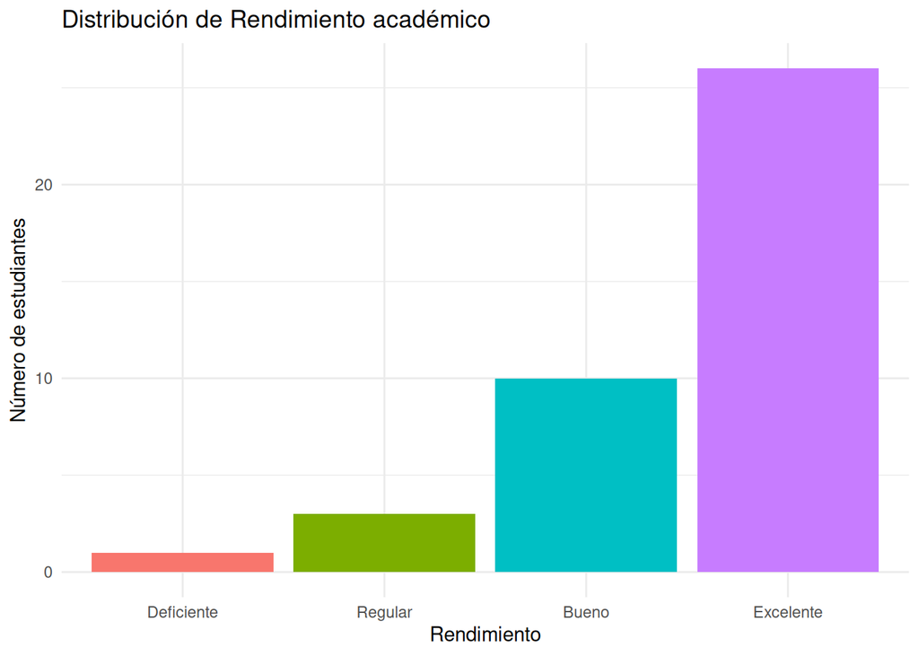

```r
ggplot(datos, aes(x = Rendimiento, fill = Rendimiento)) +
  geom_bar() +
  labs(title = "Distribución de Rendimiento académico",
       x = "Rendimiento", y = "Número de estudiantes") +
  theme_minimal() +
  theme(legend.position = "none")
```

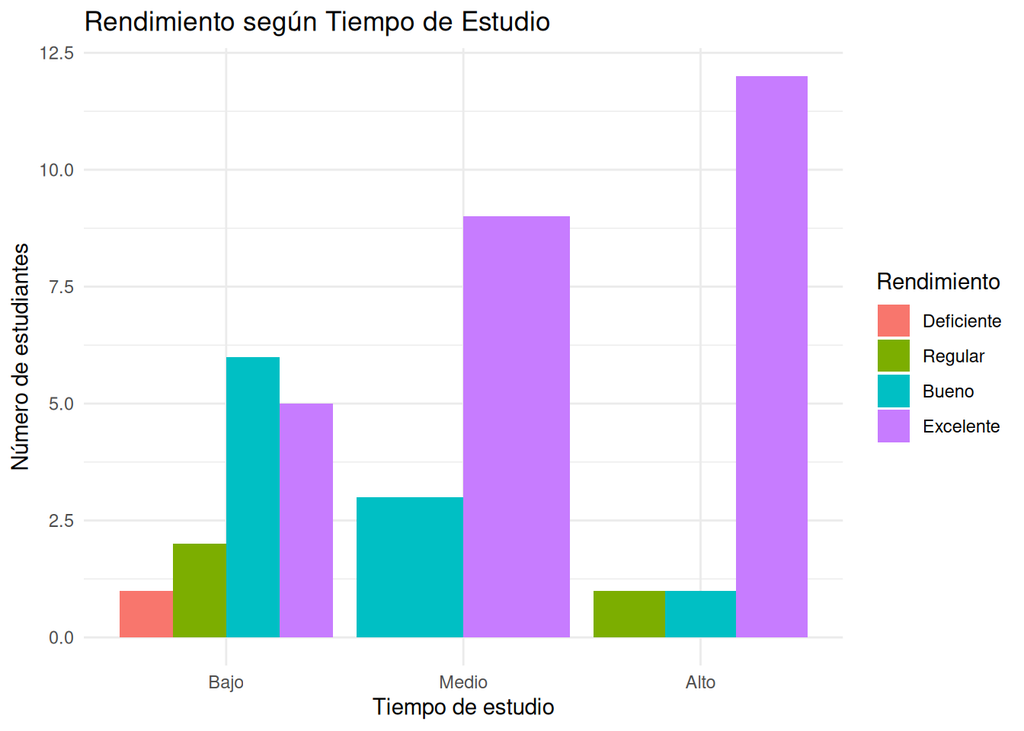

```r
ggplot(datos, aes(x = TiempoEstudio, fill = Rendimiento)) +
  geom_bar(position = "dodge") +
  labs(title = "Rendimiento según Tiempo de Estudio",
       x = "Tiempo de estudio", y = "Número de estudiantes") +
  theme_minimal()
```

# 5 Partición de datos (80% entrenamiento / 20% prueba)

```r
set.seed(123)
indice_train <- createDataPartition(datos$Rendimiento, p = 0.8, list = FALSE)

train_data <- datos[indice_train, -1]  # se excluye la columna Est
test_data  <- datos[-indice_train, -1]

cat("Observaciones de entrenamiento:", nrow(train_data), "\n")
```

```
## Observaciones de entrenamiento: 33
```

```r
cat("Observaciones de prueba       :", nrow(test_data), "\n")
```

```
## Observaciones de prueba       : 7
```

# 6 Entrenamiento del modelo Naive Bayes

```r
modelo_nb <- naiveBayes(Rendimiento ~ TiempoEstudio + Asistencia +
                           Participacion + SituacionEcon,
                         data = train_data)

modelo_nb
```

```
##
## Naive Bayes Classifier for Discrete Predictors
##
## Call:
## naiveBayes.default(x = X, y = Y, laplace = laplace)
##
## A-priori probabilities:
## Y
## Deficiente    Regular      Bueno  Excelente
## 0.03030303 0.09090909 0.24242424 0.63636364
##
## Conditional probabilities:
##             TiempoEstudio
## Y                 Bajo     Medio      Alto
##   Deficiente 1.0000000 0.0000000 0.0000000
##   Regular    0.6666667 0.0000000 0.3333333
##   Bueno      0.5000000 0.3750000 0.1250000
##   Excelente  0.2380952 0.3809524 0.3809524
##
##             Asistencia
## Y                 Baja     Media      Alta
##   Deficiente 1.0000000 0.0000000 0.0000000
##   Regular    0.3333333 0.6666667 0.0000000
##   Bueno      0.3750000 0.3750000 0.2500000
##   Excelente  0.1428571 0.2380952 0.6190476
##
##             Participacion
## Y                 Baja     Media      Alta
##   Deficiente 1.0000000 0.0000000 0.0000000
##   Regular    1.0000000 0.0000000 0.0000000
##   Bueno      0.2500000 0.5000000 0.2500000
##   Excelente  0.0952381 0.3333333 0.5714286
##
##             SituacionEcon
## Y                 Mala     Buena
##   Deficiente 1.0000000 0.0000000
##   Regular    0.0000000 1.0000000
##   Bueno      0.5000000 0.5000000
##   Excelente  0.4285714 0.5714286
```

# 7 Predicción sobre el conjunto de prueba

```r
predicciones <- predict(modelo_nb, newdata = test_data)

resultado <- data.frame(
  Real      = test_data$Rendimiento,
  Predicho  = predicciones
)
resultado
```

```
##        Real  Predicho
## 1     Bueno Excelente
## 2 Excelente Excelente
## 3 Excelente Excelente
## 4 Excelente Excelente
## 5     Bueno Excelente
## 6 Excelente Excelente
## 7 Excelente Excelente
```

# 8 Matriz de confusión

```r
matriz_confusion <- confusionMatrix(predicciones, test_data$Rendimiento)
matriz_confusion
```

```
## Confusion Matrix and Statistics
##
##             Reference
## Prediction   Deficiente Regular Bueno Excelente
##   Deficiente          0       0     0         0
##   Regular             0       0     0         0
##   Bueno               0       0     0         0
##   Excelente           0       0     2         5
##
## Overall Statistics
##
##                Accuracy : 0.7143
##                  95% CI : (0.2904, 0.9633)
##     No Information Rate : 0.7143
##     P-Value [Acc > NIR] : 0.6792
##
##                   Kappa : 0
##
##  Mcnemar's Test P-Value : NA
##
## Statistics by Class:
##
##                      Class: Deficiente Class: Regular Class: Bueno
## Sensitivity                         NA             NA       0.0000
## Specificity                          1              1       1.0000
## Pos Pred Value                      NA             NA          NaN
## Neg Pred Value                      NA             NA       0.7143
## Prevalence                           0              0       0.2857
## Detection Rate                       0              0       0.0000
## Detection Prevalence                 0              0       0.0000
## Balanced Accuracy                   NA             NA       0.5000
##                      Class: Excelente
## Sensitivity                    1.0000
## Specificity                    0.0000
## Pos Pred Value                 0.7143
## Neg Pred Value                    NaN
## Prevalence                     0.7143
## Detection Rate                 0.7143
## Detection Prevalence           1.0000
## Balanced Accuracy              0.5000
```

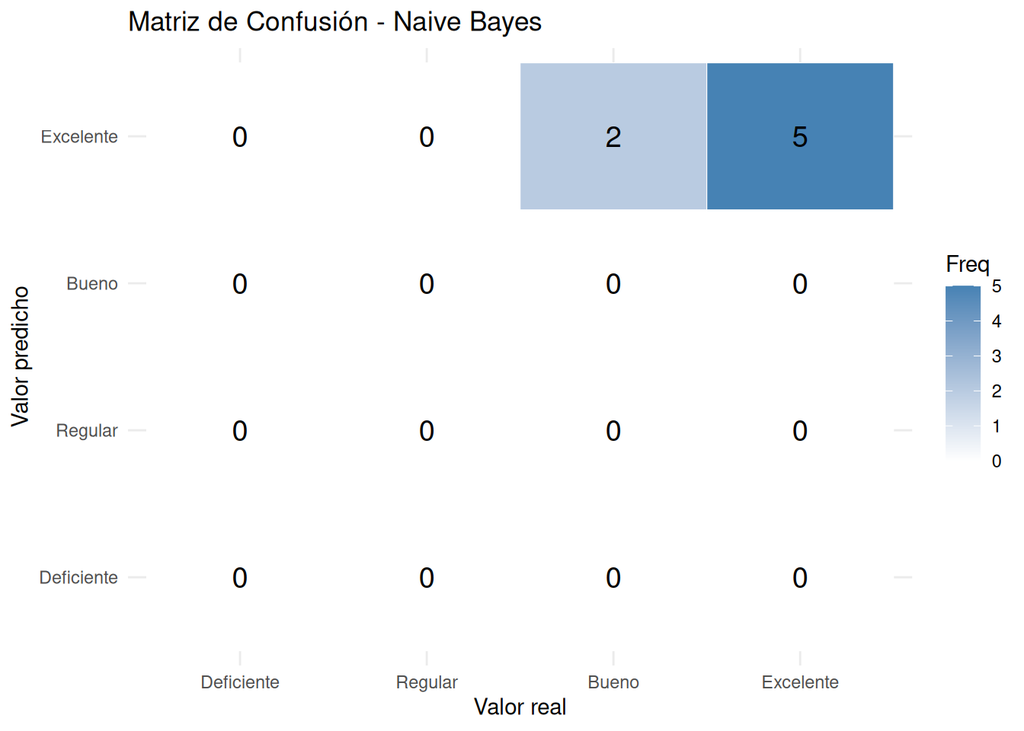

```r
cm_df <- as.data.frame(matriz_confusion$table)

ggplot(cm_df, aes(x = Reference, y = Prediction, fill = Freq)) +
  geom_tile(color = "white") +
  geom_text(aes(label = Freq), size = 5) +
  scale_fill_gradient(low = "white", high = "steelblue") +
  labs(title = "Matriz de Confusión - Naive Bayes",
       x = "Valor real", y = "Valor predicho") +
  theme_minimal()
```

# 9 Conclusiones

- La exactitud (Accuracy) global del modelo fue de **71.4%** sobre el conjunto de prueba.
- Las variables **Tiempo de estudio** y **Asistencia** parecen tener mayor relación con un Rendimiento Excelente/Bueno, mientras que valores Bajos en estas variables tienden a asociarse con Rendimiento Regular/Deficiente.
- Dado el tamaño reducido de la muestra (n = 40), los resultados deben interpretarse con cautela; un conjunto de datos más grande permitiría estimaciones de probabilidad más robustas para Naive Bayes.
- Se recomienda complementar este análisis con otros algoritmos de clasificación (árboles de decisión, kNN) para comparar el desempeño.